# NCRO Data Issues

Dave Bosworth

April 28, 2023

# Purpose

Identify and highlight issues in the NCRO data set that need to be addressed before latest EDI publication of `discretewq`.

# Global code and functions

```r
# Load packages
library(tidyverse)
library(readxl)
library(jsonlite)
library(glue)
library(scales)
library(here)
library(conflicted)
conflicts_prefer(dplyr::filter())
```

# Import and Prepare Data

```r
# Import original NCRO data files
df_ncro_cdrs <- read_excel(here("data-raw/NCRO/WQES Central Delta and Rock Slough Sample Results 2001-2021.xlsx"))
df_ncro_nd <- read_excel(here("data-raw/NCRO/WQES North Delta Sample Results 2015 - 2021.xlsx"))
df_ncro_sd <- read_excel(here("data-raw/NCRO/WQES South Delta Sample Results 1999-2021.xlsx"))

# Import station and analyte look up tables
stations <- read_csv(here("data-raw/NCRO/stationLatLongs.csv"))
analytes <- read_csv(here("data-raw/NCRO/Analytes.csv"))
```

```r
# Combine original NCRO data files and prepare for further analysis
df_ncro_all <- bind_rows(df_ncro_cdrs, df_ncro_nd, df_ncro_sd) %>%
  # only include normal samples
  filter(`Sample Type` == "Normal Sample") %>%
  # Join table with standardized analyte names
  left_join(analytes, by = join_by(Analyte)) %>%
  # only include analytes marked as "Y" in table
  filter(UseYN == "Y") %>%
  # join station info from stations table
  left_join(stations, by = join_by(`Long Station Name`)) %>%
  transmute(
    DataStatus = `Data Status`,
    StationName = `Long Station Name`,
    ShortStationName = `Short Station Name`,
    StationNumber = `Station Number`,
    SampleCode = `Sample Code`,
    DateTime = mdy_hm(`Collection Date`, tz = "Etc/GMT+8"),
    Date = date(DateTime),
    Analyte,
    AnalyteAbbr = Abbreviation,
    Result,
    # add ResultSign which indicates <RL values
    ResultSign = if_else(str_detect(Result, "^<"), "<", "="),
    RL = `Rpt Limit`,
    Units,
    Method,
    Depth,
    Matrix,
    Description,
    Notes,
    ResultRejected = `Result Rejected`,
    Latitude,
    Longitude
  ) %>%
  # remove stations with no station name or number
  filter(!str_detect(StationName, "^\\(")) %>%
  # convert Result to numeric making <RL values equal to their RL
  mutate(
    Result = case_when(
      Result %in% c("N.S.", "D1") ~ NA_character_,
      ResultSign == "<" ~ RL,
      TRUE ~ Result
    ),
    Result = as.numeric(Result)
  ) %>%
  # remove rows with NA values in Result
  drop_na(Result)
```

It turns out that most of the data NCRO collects is available on the CNRA data portal. We can download data directly into R with their data API. Let’s download and prepare that data as well, and then compare it to the data provided directly by NCRO staff.

```r
# Function to import DWR lab data from CNRA data portal by Station Number
import_lab_data <- function(StationNumber) {
  # Import first row of data to access total number of rows in data set
  import1 <- fromJSON(glue("https://data.cnra.ca.gov/api/3/action/datastore_search?resource_id=a9e7ef50-54c3-4031-8e44-aa46f3c660fe&q={StationNumber}&limit=1"))
  # Pull out total number of rows in data set
  total_res <- import1$result$total
  # Import all data
  import_total <- fromJSON(glue("https://data.cnra.ca.gov/api/3/action/datastore_search?resource_id=a9e7ef50-54c3-4031-8e44-aa46f3c660fe&q={StationNumber}&limit={total_res}"))

  # Convert to tibble and format data
  as_tibble(import_total$result$records) %>%
    select(
      DataStatus = status,
      StationName = full_station_name,
      ShortStationName = station_name,
      StationNumber = station_number,
      SampleCode = sample_code,
      DateTime = sample_date,
      Analyte = parameter,
      Result = result,
      RL = reporting_limit,
      Units = units,
      Method = method_name,
      Depth = sample_depth,
      DepthUnits = sample_depth_units,
      Latitude = latitude,
      Longitude = longitude
    ) %>%
    mutate(DateTime = ymd_hms(DateTime, tz = "Etc/GMT+8"))
}

# Function to import DWR lab data from CNRA data portal by Station Number
import_field_data <- function(StationNumber) {
  # Import first row of data to access total number of rows in data set
  import1 <- fromJSON(glue("https://data.cnra.ca.gov/api/3/action/datastore_search?resource_id=1911e554-37ab-44c0-89b0-8d7044dd891d&q={StationNumber}&limit=1"))
  # Pull out total number of rows in data set
  total_res <- import1$result$total
  # Import all data
  import_total <- fromJSON(glue("https://data.cnra.ca.gov/api/3/action/datastore_search?resource_id=1911e554-37ab-44c0-89b0-8d7044dd891d&q={StationNumber}&limit={total_res}"))

  # Convert to tibble and format data
  as_tibble(import_total$result$records) %>%
    select(
      DataStatus = status,
      StationName = full_station_name,
      ShortStationName = station_name,
      StationNumber = station_number,
      SampleCode = sample_code,
      DateTime = sample_date,
      Analyte = parameter,
      Result = fdr_result,
      RL = fdr_reporting_limit,
      Units = uns_name,
      Method = mth_name,
      Depth = sample_depth,
      DepthUnits = sample_depth_units,
      Latitude = latitude,
      Longitude = longitude
    ) %>%
    mutate(DateTime = ymd_hms(DateTime, tz = "Etc/GMT+8"))
}
```

```r
# Create a vector of all NCRO StationNumbers
ncro_sta_num <- unique(df_ncro_all$StationNumber) %>% str_subset("^\\(", negate = TRUE)

# Import all NCRO lab data from CNRA data portal
df_cnra_lab <- map(ncro_sta_num, import_lab_data) %>% list_rbind()

# Import all NCRO field data from CNRA data portal
df_cnra_fd <- map(ncro_sta_num, import_field_data) %>% list_rbind()

# Combine lab and field data and save as rds file
bind_rows(df_cnra_lab, df_cnra_fd) %>% saveRDS(file = here("publication/ncro/cnra_download.rds"))
```

Bring in and prepare NCRO data downloaded from the CNRA data portal for comparison.

```r
df_ncro_cnra <- readRDS(here("publication/ncro/cnra_download.rds")) %>%
  # Standardize a few analyte names so join works correctly
  mutate(
    Analyte = case_match(
      Analyte,
      "(Bottom) DissolvedOxygen" ~ "Field (Bottom) Dissolved Oxygen",
      "DissolvedOxygen" ~ "Field Dissolved Oxygen",
      "SpecificConductance" ~ "Field Specific Conductance",
      "WaterTemperature" ~ "Field Water Temperature",
      "pH" ~ "Field pH",
      .default = Analyte
    )
  ) %>%
  # Join table with standardized analyte names
  left_join(analytes, by = join_by(Analyte)) %>%
  # only include analytes marked as "Y" in table
  filter(UseYN == "Y") %>%
  rename(AnalyteAbbr = Abbreviation) %>%
  relocate(AnalyteAbbr, .after = Analyte) %>%
  select(-UseYN) %>%
  # Add Date column and combine Depth and units into one column
  mutate(Date = date(DateTime), .after = DateTime) %>%
  mutate(Depth = paste(as.character(Depth), DepthUnits)) %>%
  select(-DepthUnits) %>%
  # Trim whitespace at end of strings in ShortStationName
  mutate(ShortStationName = str_trim(ShortStationName)) %>%
  # Restrict data to period of record of df_ncro_all
  filter(Date >= min(df_ncro_all$Date) & Date <= max(df_ncro_all$Date)) %>%
  # remove rows with NA values in Result for now
  drop_na(Result) %>%
  # Convert Result and RL to numeric
  mutate(across(c(Result, RL), as.numeric)) %>%
  # Remove one negative Turbidity value
  filter(Result >= 0) %>%
  # We'll define <RL values as those equal to zero
  mutate(ResultSign = if_else(Result == 0, "<", "="), .after = Result) %>%
  mutate(Result = if_else(ResultSign == "<", RL, Result)) %>%
  select(-RL)
```

# Data from data request

We’ll take a closer look at the data provided directly by NCRO before we compare it to the data downloaded from the CNRA data portal. We’ll start by looking at the number of `NA` values in each column.

```r
df_ncro_all %>%
  summarize(across(everything(), ~ sum(is.na(.x)))) %>%
  pivot_longer(cols = everything(), names_to = "Column", values_to = "NumNA") %>%
  print(n = 25)
```

```
## # A tibble: 21 × 2
##    Column           NumNA
##    <chr>            <int>
##  1 DataStatus           0
##  2 StationName          0
##  3 ShortStationName     0
##  4 StationNumber        0
##  5 SampleCode           0
##  6 DateTime             0
##  7 Date                 0
##  8 Analyte              0
##  9 AnalyteAbbr          0
## 10 Result               0
## 11 ResultSign           0
## 12 RL                 486
## 13 Units                0
## 14 Method               0
## 15 Depth                0
## 16 Matrix               0
## 17 Description      80628
## 18 Notes            84097
## 19 ResultRejected     143
## 20 Latitude         28211
## 21 Longitude        28211
```

Overall, the important columns don’t have missing values. Next, let’s look at the unique values in some of the less-used columns.

```r
df_ncro_all_lu <- df_ncro_all %>%
  select(
    Depth,
    Matrix,
    Description,
    Notes,
    ResultRejected
  )

for (var in names(df_ncro_all_lu)) {
  df_ncro_all_lu %>% count(.data[[var]]) %>% print(n = 150)
}
```

```
## # A tibble: 9 × 2
##   Depth          n
##   <chr>      <int>
## 1 .1 Meters     26
## 2 .15 Meters   107
## 3 .25 Meters    58
## 4 .3 Meters    443
## 5 .5 Meters    828
## 6 .75 Meters     5
## 7 0 Meters      13
## 8 1 Feet       102
## 9 1 Meters   83501
## # A tibble: 1 × 2
##   Matrix             n
##   <chr>          <int>
```

[output cut: 210 more lines]

It looks like the sample matrix for all samples is “Water, Natural” and there were no rejected results. We can remove the columns for these. We can also remove the `RL` column since that is no longer necessary. There seems to be some variation in sample depths with some possible errors, but they were all collected at the surface.

```r
# Remove columns for Sample Matrix and Result Rejected
df_ncro_all_c1 <- df_ncro_all %>% select(-c(RL, Matrix, ResultRejected))
```

## Stations

First, let’s look to see how the station names and station numbers match up, and look for any synonyms in the station names.

```r
df_ncro_all_c1 %>%
  count(StationNumber, StationName, ShortStationName) %>%
  arrange(StationNumber) %>%
  print(n = 80)
```

```
## # A tibble: 76 × 4
##    StationNumber StationName                              ShortStationName     n
##    <chr>         <chr>                                    <chr>            <int>
##  1 (NONE)        Old River near Bacon Island @ USGS Pile  ( None )             9
##  2 (NONE)        Veale Drain                              ( None )             3
##  3 (UserDefined) COP/MSS/Paradise Cut                     (User Defined)      66
##  4 (UserDefined) Holland Cut at Holland Marina            (User Defined)      71
##  5 (UserDefined) Middle River @ Undine Road               (User Defined)       6
##  6 (UserDefined) Middle River near Tracy Road             (User Defined)     136
##  7 (UserDefined) Old River at Bacon Island                (User Defined)     283
##  8 (UserDefined) Old River at Bacon Island                Old River @ Bac…   485
##  9 (UserDefined) Old River near Bacon Island @ USGS Pile  Old River at Ba…    94
## 10 (UserDefined) PC11                                     (User Defined)      12
## 11 (UserDefined) Rock Slough - 100 yards East of Veale D… (User Defined)      52
## 12 (UserDefined) Rock Slough - 100 yards East of Veale D… Rock Slough - 1…     9
```

[output cut: 64 more lines]

None of the station numbers are duplicated with different station names, but there are a few stations with (UserDefined) as their station numbers that need to be standardized. Now let’s take a look at the stations without matches in the stations table. These are currently excluded from the data publication.

```r
df_ncro_all_c1 %>%
  # Records without Latitude-Longitude coordinates are not in the stations table
  filter(is.na(Latitude)) %>%
  count(StationName, ShortStationName, StationNumber) %>%
  arrange(desc(n)) %>%
  print(n = 40)
```

```
## # A tibble: 34 × 4
##    StationName                              ShortStationName StationNumber     n
##    <chr>                                    <chr>            <chr>         <int>
##  1 Old River below Headwaters               OLD R BL HEAD    B9D74851200    3760
##  2 Old River Downstream DMC Barrier         OR@DMC-DS        B9536500       3700
##  3 Old River above DMC Barrier              OR@DMC-US        B9536600       3305
##  4 Middle River @ Union Point - P10A        MR@UnionPt/P10A  B9D75351292    3277
##  5 Grant Ln Can @ Tracy Rd Bdg              GLC@Tracy        B9D74921269    3121
##  6 Grantline Canal above Dam                GLCaboveDam      B9D74921510    2261
##  7 Old River @ Tracy Road Bridge - P12      P12 - OR@TracyR… B9D74831270    1678
##  8 Middle R @ Tracy Rd Bdg                  MRIVTRACY        B9D75291273    1608
##  9 Old River near Doughty Cut - ORX         OR Nr DOUGHTY C… B9D74871232    1131
## 10 Steamboat Slough                         Steamboat Slough B9S81131386     990
## 11 Sugar Cut downstream of Tom Paine Slough SUGAR CUT        B9D74761253     738
## 12 Contra Costa PP Number 01                CONCOSPP1        B9591000        727
```

[output cut: 22 more lines]

There are 18 excluded stations that have over 100 records, and there are two additional stations with established Station Numbers. We may want to include some or all of these.

## Analytes

Next, let’s take a look at the analytes, their abbreviations and methods.

```r
df_ncro_all_c1 %>%
  count(AnalyteAbbr, Analyte, Method) %>%
  arrange(AnalyteAbbr) %>%
  print(n = 50)
```

```
## # A tibble: 45 × 4
##    AnalyteAbbr            Analyte                           Method             n
##    <chr>                  <chr>                             <chr>          <int>
##  1 Chlorophyll            Chlorophyll a                     Std Method 10…  6831
##  2 Conductivity_top       Field Specific Conductance        EPA 120.1 (Fi…  9820
##  3 Conductivity_top       Specific Conductance              Std Method 25…   433
##  4 Conductivity_top       Specific Conductance              Std Method 25…   171
##  5 DOC                    Dissolved Organic Carbon          EPA 415.1 (D)…   693
##  6 DOC                    Dissolved Organic Carbon          EPA 415.3 (D)…   519
##  7 DON                    Dissolved Organic Nitrogen        EPA 351.2/EPA…  2296
##  8 DON                    Dissolved Organic Nitrogen        EPA 351.2/EPA…    65
##  9 DissAmmonia            Dissolved Ammonia                 EPA 350.1 (D)…    78
## 10 DissAmmonia            Dissolved Ammonia                 EPA 350.1 DWR…  2404
## 11 DissBromide            Dissolved Bromide                 EPA 300.0 28d…  4487
## 12 DissBromide            Dissolved Bromide                 EPA 300.0 [1]*   387
```

[output cut: 33 more lines]

Some of nutrients and cations have had method changes throughout the years; however, a few issues jump out:

1. The analyte “Specific Conductance” may actually be a laboratory measurement, which we would most likely exclude. We’ll need to look into this further.
2. There are a significant number of Turbidity samples measured with method “EPA 180.1 [D-2]*“. These also could be laboratory measurements, which we would also exclude. We’ll need to look into this further as well.
3. “Dissolved Total Kjeldahl Nitrogen” is not an actual analyte and should be removed.
4. Total Dissolved Solids is not TSS and should be a separate analyte abbreviated as TDS.
5. Some of the Turbidity measurements are made with a sonde. We’ll need to make sure their units are FNU, not NTU.

Let’s fix issues 3 and 4 above:

```r
df_ncro_all_c2 <- df_ncro_all_c1 %>%
  filter(Analyte != "Dissolved Total Kjeldahl Nitrogen") %>%
  mutate(AnalyteAbbr = if_else(Analyte == "Total Dissolved Solids", "TDS", AnalyteAbbr))

# Make sure they are fixed
df_ncro_all_c2 %>%
  count(AnalyteAbbr, Analyte, Method) %>%
  arrange(AnalyteAbbr) %>%
  print(n = 50)
```

```
## # A tibble: 44 × 4
##    AnalyteAbbr            Analyte                         Method               n
##    <chr>                  <chr>                           <chr>            <int>
##  1 Chlorophyll            Chlorophyll a                   Std Method 1020…  6831
##  2 Conductivity_top       Field Specific Conductance      EPA 120.1 (Fiel…  9820
##  3 Conductivity_top       Specific Conductance            Std Method 2510…   433
##  4 Conductivity_top       Specific Conductance            Std Method 2510…   171
##  5 DOC                    Dissolved Organic Carbon        EPA 415.1 (D) O…   693
##  6 DOC                    Dissolved Organic Carbon        EPA 415.3 (D) […   519
##  7 DON                    Dissolved Organic Nitrogen      EPA 351.2/EPA 3…  2296
##  8 DON                    Dissolved Organic Nitrogen      EPA 351.2/EPA 3…    65
##  9 DissAmmonia            Dissolved Ammonia               EPA 350.1 (D) […    78
## 10 DissAmmonia            Dissolved Ammonia               EPA 350.1 DWR M…  2404
## 11 DissBromide            Dissolved Bromide               EPA 300.0 28d H…  4487
## 12 DissBromide            Dissolved Bromide               EPA 300.0 [1]*     387
```

[output cut: 32 more lines]

Now let’s take a closer look at issue 1 to see if “Field Specific Conductance” was collected alongside the “Specific Conductance” measurements.

```r
# Find all SampleCodes where "Field Specific Conductance" was collected
  # along with "Specific Conductance"
df_ncro_all_c2 %>%
  filter(Analyte == "Specific Conductance") %>%
  left_join(
    df_ncro_all_c2 %>% filter(Analyte == "Field Specific Conductance"),
    by = join_by(SampleCode)
  ) %>%
  filter(!is.na(Analyte.y)) %>%
  nrow()
```

```
## [1] 594
```

```r
# Find all SampleCodes where "Field Specific Conductance" wasn't collected
  # along with "Specific Conductance"
df_ncro_all_c2 %>%
  filter(Analyte == "Specific Conductance") %>%
  left_join(
    df_ncro_all_c2 %>% filter(Analyte == "Field Specific Conductance"),
    by = join_by(SampleCode)
  ) %>%
  filter(is.na(Analyte.y)) %>%
  nrow()
```

```
## [1] 10
```

It looks like most the Sample Codes with “Specific Conductance” as an analyte also have “Field Specific Conductance”. There are only 10 Sample Codes that have only “Specific Conductance” as an analyte. We will remove all records with “Specific Conductance” as an analyte since they are most likely laboratory measurements.

```r
df_ncro_all_c3 <- df_ncro_all_c2 %>% filter(Analyte != "Specific Conductance")
```

We’ll take a closer look at issue 2 to see if the Turbidity measurements with Method “EPA 180.1 [D-2]*” were collected alongside a field Turbidity measurement.

```r
# Find all SampleCodes where "Field Turbidity" was collected along with "Turbidity"
df_ncro_all_c3 %>%
  filter(Method == "EPA 180.1 [D-2]*") %>%
  left_join(
    df_ncro_all_c3 %>% filter(Analyte == "Field Turbidity"),
    by = join_by(SampleCode)
  ) %>%
  filter(!is.na(Analyte.y)) %>%
  nrow()
```

```
## [1] 0
```

None of the Turbidity measurements with Method “EPA 180.1 [D-2]*” were collected alongside a field Turbidity measurement. These may all be synonyms for field-collected Turbidity, but we should check on this to confirm.

Let’s take a look at the Analytes and their units including Turbidity to address issue 5.

```r
df_ncro_all_c3 %>%
  count(AnalyteAbbr, Analyte, Method, Units) %>%
  arrange(AnalyteAbbr) %>%
  print(n = 50)
```

```
## # A tibble: 46 × 5
##    AnalyteAbbr            Analyte                         Method     Units     n
##    <chr>                  <chr>                           <chr>      <chr> <int>
##  1 Chlorophyll            Chlorophyll a                   Std Metho… ug/L   6831
##  2 Conductivity_top       Field Specific Conductance      EPA 120.1… uS/c…  9820
##  3 DOC                    Dissolved Organic Carbon        EPA 415.1… mg/L…   693
##  4 DOC                    Dissolved Organic Carbon        EPA 415.3… mg/L…   519
##  5 DON                    Dissolved Organic Nitrogen      EPA 351.2… mg/L…  2296
##  6 DON                    Dissolved Organic Nitrogen      EPA 351.2… mg/L…    65
##  7 DissAmmonia            Dissolved Ammonia               EPA 350.1… mg/L…    78
##  8 DissAmmonia            Dissolved Ammonia               EPA 350.1… mg/L      1
##  9 DissAmmonia            Dissolved Ammonia               EPA 350.1… mg/L…  2403
## 10 DissBromide            Dissolved Bromide               EPA 300.0… mg/L   4487
## 11 DissBromide            Dissolved Bromide               EPA 300.0… mg/L    387
## 12 DissCalcium            Dissolved Calcium               EPA 200.7… mg/L    380
```

[output cut: 34 more lines]

Most of the units are consistent among analytes and their methods including Turbidity. There are 13 Dissolved Calcium records with “ug/L” as their unit of measure, while the majority of records for this analyte have “mg/L” as their unit of measure. These 13 records will need to be converted to mg/L.

```r
df_ncro_all_c4 <- df_ncro_all_c3 %>%
  mutate(
    Result = if_else(Analyte == "Dissolved Calcium" & Units == "ug/L", Result / 1000, Result),
    Units = if_else(Analyte == "Dissolved Calcium" & Units == "ug/L", "mg/L", Units)
  )

# Make sure they are fixed
df_ncro_all_c4 %>%
  count(AnalyteAbbr, Analyte, Method, Units) %>%
  arrange(AnalyteAbbr) %>%
  print(n = 50)
```

```
## # A tibble: 45 × 5
##    AnalyteAbbr            Analyte                         Method     Units     n
##    <chr>                  <chr>                           <chr>      <chr> <int>
##  1 Chlorophyll            Chlorophyll a                   Std Metho… ug/L   6831
##  2 Conductivity_top       Field Specific Conductance      EPA 120.1… uS/c…  9820
##  3 DOC                    Dissolved Organic Carbon        EPA 415.1… mg/L…   693
##  4 DOC                    Dissolved Organic Carbon        EPA 415.3… mg/L…   519
##  5 DON                    Dissolved Organic Nitrogen      EPA 351.2… mg/L…  2296
##  6 DON                    Dissolved Organic Nitrogen      EPA 351.2… mg/L…    65
##  7 DissAmmonia            Dissolved Ammonia               EPA 350.1… mg/L…    78
##  8 DissAmmonia            Dissolved Ammonia               EPA 350.1… mg/L      1
##  9 DissAmmonia            Dissolved Ammonia               EPA 350.1… mg/L…  2403
## 10 DissBromide            Dissolved Bromide               EPA 300.0… mg/L   4487
## 11 DissBromide            Dissolved Bromide               EPA 300.0… mg/L    387
## 12 DissCalcium            Dissolved Calcium               EPA 200.7… mg/L    393
```

[output cut: 33 more lines]

## Duplicate records

Let’s look for and remove any duplicate samples - more than 1 sample collected at a station and same `DateTime`.

```r
df_ncro_all_c4 %>%
  count(StationName, DateTime, Analyte) %>%
  filter(n > 1) %>%
  nrow()
```

```
## [1] 3703
```

```r
# Pull out duplicate records
df_ncro_all_dups <- df_ncro_all_c4 %>%
  count(StationName, DateTime, Analyte) %>%
  filter(n > 1) %>%
  select(-n) %>%
  left_join(df_ncro_all_c4, by = join_by(StationName, DateTime, Analyte))
```

There are 3703 instances when more than one sample was collected at a station and same `DateTime`. Let’s see if there is any way to determine which record is the Duplicate QA sample, so we can remove those.

```r
df_ncro_all_dups %>% count(Notes)
```

```
## # A tibble: 7 × 2
##   Notes                                                                        n
##   <chr>                                                                    <int>
## 1 DILUTION DUPLICATE                                                           1
## 2 Duplicate                                                                  551
## 3 Duplicate & Matrix Spike                                                     1
## 4 Note:  Large pieces of of suspended material present in sample ( i.e. s…     1
## 5 Sample  CF1113B0472 was originally batched with Batch: 37706.                2
## 6 laboratory-duplicate                                                         2
## 7 <NA>                                                                      7153
```

We may be able to remove the records from `df_ncro_all_dups` with the following `Notes`:

- DILUTION DUPLICATE
- Duplicate
- Duplicate & Matrix Spike
- laboratory-duplicate

Let’s see if these have matching records.

```r
# Define regex for notes for the records we are considering to remove
regex_notes_dups <- regex("duplicate", ignore_case = TRUE)

df_ncro_all_dups %>%
  filter(str_detect(Notes, regex_notes_dups)) %>%
  left_join(
    df_ncro_all_dups %>% filter(!str_detect(Notes, regex_notes_dups) | is.na(Notes)),
    by = join_by(StationName, DateTime, Analyte)
  ) %>%
  summarize(across(everything(), ~ sum(is.na(.x)))) %>%
  pivot_longer(cols = everything(), names_to = "Column", values_to = "NumNA") %>%
  print(n = 40)
```

```
## # A tibble: 33 × 2
##    Column             NumNA
##    <chr>              <int>
##  1 StationName            0
##  2 DateTime               0
##  3 Analyte                0
##  4 DataStatus.x           0
##  5 ShortStationName.x     0
##  6 StationNumber.x        0
##  7 SampleCode.x           0
##  8 Date.x                 0
##  9 AnalyteAbbr.x          0
## 10 Result.x               0
## 11 ResultSign.x           0
## 12 Units.x                0
```

[output cut: 21 more lines]

It looks like all records with the `Notes` indicated above have matching records, so it is safe to remove these.

```r
# Remove duplicates with Notes in regex_notes_dups
df_ncro_all_dups_c1 <- df_ncro_all_dups %>% filter(!str_detect(Notes, regex_notes_dups) | is.na(Notes))

# Look for more duplicates after removing records with these notes
df_ncro_all_dups_c1 %>%
  count(StationName, DateTime, Analyte) %>%
  filter(n > 1)
```

```
## # A tibble: 3,148 × 4
##    StationName                     DateTime            Analyte                 n
##    <chr>                           <dttm>              <chr>               <int>
##  1 Bethel Island near Piper Slough 2014-06-04 11:45:00 Total Phosphorus        2
##  2 Bethel Island near Piper Slough 2014-10-07 11:45:00 Dissolved Chloride      2
##  3 Bethel Island near Piper Slough 2014-10-23 12:00:00 Dissolved Bromide       2
##  4 Bethel Island near Piper Slough 2014-10-23 12:00:00 Dissolved Chloride      2
##  5 Bethel Island near Piper Slough 2015-09-15 11:00:00 Field Specific Con…     2
##  6 Bethel Island near Piper Slough 2015-09-15 11:00:00 Field Turbidity         2
##  7 Bethel Island near Piper Slough 2015-09-15 11:00:00 Field Water Temper…     2
##  8 Bethel Island near Piper Slough 2015-09-15 11:00:00 Field pH                2
##  9 Bethel Island near Piper Slough 2016-01-26 11:30:00 Total Phosphorus        2
## 10 Bethel Island near Piper Slough 2016-06-30 10:42:00 Field Specific Con…     2
## # ℹ 3,138 more rows
```

There are still a significant amount of duplicates remaining. We’ll try to fix these by keeping the first sample of the pair.

```r
df_ncro_all_dups_c2 <- df_ncro_all_dups_c1 %>%
  group_by(StationName, DateTime, Analyte) %>%
  mutate(RepNum = row_number()) %>%
  ungroup() %>%
  filter(RepNum == 1) %>%
  select(-RepNum)

# Make sure all duplicates are removed now
df_ncro_all_dups_c2 %>%
  count(StationName, DateTime, Analyte) %>%
  filter(n > 1)
```

```
## # A tibble: 0 × 4
## # ℹ 4 variables: StationName <chr>, DateTime <dttm>, Analyte <chr>, n <int>
```

We’ll add the data frame with the cleaned up duplicates back to the main data frame.

```r
df_ncro_all_c5 <- df_ncro_all_c4 %>%
  anti_join(df_ncro_all_dups) %>%
  bind_rows(df_ncro_all_dups_c2)
```

[output not shown]

```r
# Make sure all duplicates are removed now
df_ncro_all_c5 %>%
  count(StationName, DateTime, Analyte) %>%
  filter(n > 1)
```

```
## # A tibble: 0 × 4
## # ℹ 4 variables: StationName <chr>, DateTime <dttm>, Analyte <chr>, n <int>
```

All duplicates are cleaned up now. Let’s see how many instances when more than one sample was collected at a station and same day. This should be pretty rare.

```r
df_ncro_all_c5 %>%
  count(StationName, Date, Analyte) %>%
  filter(n > 1) %>%
  nrow()
```

```
## [1] 272
```

Hmmm, there are more of these than I thought. We may need to revisit this…

## Sampling effort by Station

Let’s take a look at the sampling effort by station for each year. This could help when trying to standardize station names. This will be counts of distinct sampling events (unique DateTime-Station combinations).

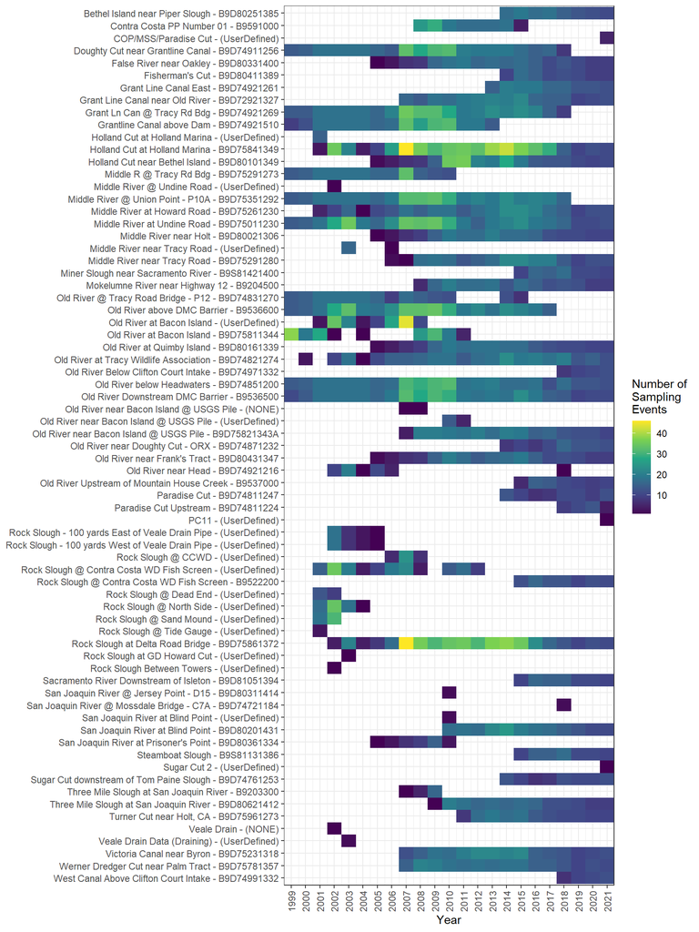

```r
# Count number of distinct sampling events by station for each year
df_ncro_all_se <- df_ncro_all_c5 %>%
  distinct(StationNumber, StationName, DateTime) %>%
  mutate(Year = year(DateTime)) %>%
  count(StationNumber, StationName, Year, name = "NumSamples") %>%
  unite(col = "Station", StationName, StationNumber, sep = " - ")

# Create heat map
df_ncro_all_se %>%
  mutate(Station = factor(Station)) %>%
  ggplot(aes(x = Year, y = fct_rev(Station), fill = NumSamples)) +
  geom_tile() +
  scale_fill_viridis_c(name = "Number of\nSampling\nEvents") +
  ylab(NULL) +
  scale_x_continuous(breaks = breaks_pretty(20), expand = expansion()) +
  theme_bw() +
  theme(axis.text.x = element_text(angle = 90, hjust = 1, vjust = 0.5))
```

# Data from CNRA data portal

We’ll take a closer look at the data downloaded from the CNRA data portal before we compare it to the data provided by NCRO. We’ll start by looking at the number of `NA` values in each column.

```r
df_ncro_cnra %>%
  summarize(across(everything(), ~ sum(is.na(.x)))) %>%
  pivot_longer(cols = everything(), names_to = "Column", values_to = "NumNA") %>%
  print(n = 20)
```

```
## # A tibble: 16 × 2
##    Column           NumNA
##    <chr>            <int>
##  1 DataStatus           0
##  2 StationName          0
##  3 ShortStationName     0
##  4 StationNumber        0
##  5 SampleCode           0
##  6 DateTime             0
##  7 Date                 0
##  8 Analyte              0
##  9 AnalyteAbbr          0
## 10 Result               0
## 11 ResultSign           0
## 12 Units                0
## 13 Method               0
## 14 Depth                0
## 15 Latitude             0
## 16 Longitude            0
```

There are no `NA` values in the data set, which is nice.

## Stations

Let’s look to see how the station names and station numbers match up, and look for any synonyms in the station names.

```r
df_ncro_cnra %>%
  count(StationNumber, StationName, ShortStationName) %>%
  arrange(StationNumber) %>%
  print(n = 50)
```

```
## # A tibble: 49 × 4
##    StationNumber StationName                              ShortStationName     n
##    <chr>         <chr>                                    <chr>            <int>
##  1 B9203300      Three Mile Slough near San Joaquin River 3 Mile Slough      133
##  2 B9204500      Mokelumne River near Highway 12          MOK near HWY 12   1484
##  3 B9522200      Rock Slough @ Contra Costa WD Fish Scre… RS @CCWD Fish S…   890
##  4 B9536500      Old River Downstream DMC Barrier         OR@DMC-DS         3636
##  5 B9536600      Old River above DMC Barrier              OR@DMC-US         3330
##  6 B9537000      Old River Upstream of Mountain House Cr… OR up Mtn House…   741
##  7 B9591000      Contra Costa PP Number 01                CONCOSPP1         2601
##  8 B9D72921327   Grant Line Canal near Old River          GLC n. OR         1883
##  9 B9D74721184   San Joaquin River @ Mossdale Bridge - C… C7A - Mossdale    1055
## 10 B9D74761253   Sugar Cut downstream of Tom Paine Slough SUGAR CUT          732
## 11 B9D74811224   Paradise Cut Upstream                    Paradise C Upst…   399
## 12 B9D74811247   Paradise Cut                             PARADISE CUT       705
```

[output cut: 37 more lines]

The station names and numbers look clean and standardized which is great.

## Analytes

Next, let’s take a look at the analytes, their abbreviations and methods.

```r
df_ncro_cnra %>%
  count(AnalyteAbbr, Analyte, Method) %>%
  arrange(AnalyteAbbr) %>%
  print(n = 50)
```

```
## # A tibble: 49 × 4
##    AnalyteAbbr            Analyte                           Method             n
##    <chr>                  <chr>                             <chr>          <int>
##  1 Chlorophyll            Chlorophyll a                     Std Method 10…  6809
##  2 Conductivity_top       Field Specific Conductance        EPA 120.1 (Fi… 10290
##  3 Conductivity_top       Specific Conductance              Std Method 25…  1055
##  4 Conductivity_top       Specific Conductance              Std Method 25…   170
##  5 DOC                    Dissolved Organic Carbon          EPA 415.1 (D)…    41
##  6 DOC                    Dissolved Organic Carbon          EPA 415.1 (D)…  1232
##  7 DOC                    Dissolved Organic Carbon          EPA 415.3 (D)    500
##  8 DON                    Dissolved Organic Nitrogen        EPA 351.2/EPA…    65
##  9 DON                    Dissolved Organic Nitrogen        EPA 351.2/EPA…  2277
## 10 DissAmmonia            Dissolved Ammonia                 EPA 350.1 (D)     89
## 11 DissAmmonia            Dissolved Ammonia                 EPA 350.1 (DW…  2854
## 12 DissBromide            Dissolved Bromide                 EPA 300.0        399
```

[output cut: 37 more lines]

As with the data from NCRO, some of nutrients and cations have had method changes throughout the years, and there are a few similar issues that jump out:

1. The analyte “Specific Conductance” may actually be a laboratory measurement, which we would most likely exclude. We’ll need to look into this further.
2. There are a significant number of Turbidity samples measured with method “EPA 180.1”. These also could be laboratory measurements, which we would also exclude. We’ll need to look into this further as well.
3. There may also be some pH records that were measured in the laboratory with “Std Method 5910B (DWR Modified)”.
4. “Dissolved Total Kjeldahl Nitrogen” is not an actual analyte and should be removed.
5. Total Dissolved Solids is not TSS and should be a separate analyte abbreviated as TDS.
6. Some of the Turbidity measurements are made with a sonde. We’ll need to make sure their units are FNU, not NTU.

Let’s fix issues 4 and 5 above:

```r
df_ncro_cnra_c1 <- df_ncro_cnra %>%
  filter(Analyte != "Dissolved Total Kjeldahl Nitrogen") %>%
  mutate(AnalyteAbbr = if_else(Analyte == "Total Dissolved Solids", "TDS", AnalyteAbbr))

# Make sure they are fixed
df_ncro_cnra_c1 %>%
  count(AnalyteAbbr, Analyte, Method) %>%
  arrange(AnalyteAbbr) %>%
  print(n = 50)
```

```
## # A tibble: 48 × 4
##    AnalyteAbbr            Analyte                         Method               n
##    <chr>                  <chr>                           <chr>            <int>
##  1 Chlorophyll            Chlorophyll a                   Std Method 1020…  6809
##  2 Conductivity_top       Field Specific Conductance      EPA 120.1 (Fiel… 10290
##  3 Conductivity_top       Specific Conductance            Std Method 2510…  1055
##  4 Conductivity_top       Specific Conductance            Std Method 2510…   170
##  5 DOC                    Dissolved Organic Carbon        EPA 415.1 (D) C…    41
##  6 DOC                    Dissolved Organic Carbon        EPA 415.1 (D) Ox  1232
##  7 DOC                    Dissolved Organic Carbon        EPA 415.3 (D)      500
##  8 DON                    Dissolved Organic Nitrogen      EPA 351.2/EPA 3…    65
##  9 DON                    Dissolved Organic Nitrogen      EPA 351.2/EPA 3…  2277
## 10 DissAmmonia            Dissolved Ammonia               EPA 350.1 (D)       89
## 11 DissAmmonia            Dissolved Ammonia               EPA 350.1 (DWR …  2854
## 12 DissBromide            Dissolved Bromide               EPA 300.0          399
```

[output cut: 36 more lines]

Now let’s take a closer look at issue 1 to see if “Field Specific Conductance” was collected alongside the “Specific Conductance” measurements.

```r
# Find all SampleCodes where "Field Specific Conductance" was collected
  # along with "Specific Conductance"
df_ncro_cnra_c1 %>%
  filter(Analyte == "Specific Conductance") %>%
  left_join(
    df_ncro_cnra_c1 %>% filter(Analyte == "Field Specific Conductance"),
    by = join_by(SampleCode)
  ) %>%
  filter(!is.na(Analyte.y)) %>%
  nrow()
```

```
## [1] 1213
```

```r
# Find all SampleCodes where "Field Specific Conductance" wasn't collected
  # along with "Specific Conductance"
df_ncro_cnra_c1 %>%
  filter(Analyte == "Specific Conductance") %>%
  left_join(
    df_ncro_cnra_c1 %>% filter(Analyte == "Field Specific Conductance"),
    by = join_by(SampleCode)
  ) %>%
  filter(is.na(Analyte.y)) %>%
  nrow()
```

```
## [1] 12
```

It looks like most the Sample Codes with “Specific Conductance” as an analyte also have “Field Specific Conductance”. There are only 12 Sample Codes that have only “Specific Conductance” as an analyte. We will remove all records with “Specific Conductance” as an analyte since they are most likely laboratory measurements.

```r
df_ncro_cnra_c2 <- df_ncro_cnra_c1 %>% filter(Analyte != "Specific Conductance")
```

We’ll take a closer look at issue 2 to see if the Turbidity measurements with Method “EPA 180.1” were collected alongside a field Turbidity measurement.

```r
# Find all SampleCodes where "Field Turbidity" was collected along with "Turbidity"
df_ncro_cnra_c2 %>%
  filter(Method == "EPA 180.1") %>%
  left_join(
    df_ncro_cnra_c2 %>% filter(Method %in% c("EPA 180.1 (Field)", "Turbidity, Sonde")),
    by = join_by(SampleCode)
  ) %>%
  filter(!is.na(Analyte.y)) %>%
  nrow()
```

```
## [1] 554
```

```r
# Find all SampleCodes where "Field Turbidity" wasn't collected along with "Turbidity"
df_ncro_cnra_c2 %>%
  filter(Method == "EPA 180.1") %>%
  left_join(
    df_ncro_cnra_c2 %>% filter(Method %in% c("EPA 180.1 (Field)", "Turbidity, Sonde")),
    by = join_by(SampleCode)
  ) %>%
  filter(is.na(Analyte.y)) %>%
  nrow()
```

```
## [1] 1883
```

Hmm, this is kind of a mystery. Some of the SampleCodes have both “Turbidity” and “Field Turbidity” samples, but a majority of SampleCodes when “Turbidity” was collected don’t have an associated “Field Turbidity” sample. We may have to remove the 554 “Turbidity” samples that have an associated “Field Turbidity” sample, but keep the remaining 1883 “Turbidity” samples. This may be something to look into further…

Next, let’s take a look at issue 3 to see if the pH measurements with Method “Std Method 5910B (DWR Modified)” were collected alongside a field pH measurement.

```r
# Find all SampleCodes where "Field pH" was collected along with "pH"
df_ncro_cnra_c2 %>%
  filter(Method == "Std Method 5910B (DWR Modified)") %>%
  left_join(
    df_ncro_cnra_c2 %>% filter(Method %in% c("EPA 150.1 (Field)", "SM 4500-H B-2000 (Field)")),
    by = join_by(SampleCode)
  ) %>%
  filter(!is.na(Analyte.y)) %>%
  nrow()
```

```
## [1] 40
```

```r
# Find all SampleCodes where "Field pH" wasn't collected along with "pH"
df_ncro_cnra_c2 %>%
  filter(Method == "Std Method 5910B (DWR Modified)") %>%
  left_join(
    df_ncro_cnra_c2 %>% filter(Method %in% c("EPA 150.1 (Field)", "SM 4500-H B-2000 (Field)")),
    by = join_by(SampleCode)
  ) %>%
  filter(is.na(Analyte.y)) %>%
  nrow()
```

```
## [1] 1
```

It looks like almost the Sample Codes with “pH” as an analyte also have “Field pH”. There is only 1 Sample Code that has only “pH” as an analyte. We will remove all records with “Std Method 5910B (DWR Modified)” as an method since they are most likely laboratory measurements.

```r
df_ncro_cnra_c3 <- df_ncro_cnra_c2 %>% filter(Method != "Std Method 5910B (DWR Modified)")
```

```r
df_ncro_cnra_c3 %>%
  count(AnalyteAbbr, Analyte, Method, Units) %>%
  arrange(AnalyteAbbr) %>%
  print(n = 50)
```

```
## # A tibble: 47 × 5
##    AnalyteAbbr            Analyte                         Method     Units     n
##    <chr>                  <chr>                           <chr>      <chr> <int>
##  1 Chlorophyll            Chlorophyll a                   Std Metho… ug/L   6809
##  2 Conductivity_top       Field Specific Conductance      EPA 120.1… uS/c… 10290
##  3 DOC                    Dissolved Organic Carbon        EPA 415.1… mg/L…    41
##  4 DOC                    Dissolved Organic Carbon        EPA 415.1… mg/L…  1232
##  5 DOC                    Dissolved Organic Carbon        EPA 415.3… mg/L…   500
##  6 DON                    Dissolved Organic Nitrogen      EPA 351.2… mg/L…    65
##  7 DON                    Dissolved Organic Nitrogen      EPA 351.2… mg/L…  2277
##  8 DissAmmonia            Dissolved Ammonia               EPA 350.1… mg/L…    89
##  9 DissAmmonia            Dissolved Ammonia               EPA 350.1… mg/L…  2854
## 10 DissBromide            Dissolved Bromide               EPA 300.0  mg/L    399
## 11 DissBromide            Dissolved Bromide               EPA 300.0… mg/L   4349
## 12 DissBromide            Dissolved Bromide               Std Metho… mg/L      1
```

[output cut: 35 more lines]

Most of the units are consistent among analytes and their methods including Turbidity. There are 5 Dissolved Calcium records with “ug/L” as their unit of measure, while the majority of records for this analyte have “mg/L” as their unit of measure. These 5 records will need to be converted to mg/L. In addition, there are 2 Water Temperature measurements that need to be converted from degrees F to degrees C.

```r
df_ncro_cnra_c4 <- df_ncro_cnra_c3 %>%
  mutate(
    Result = case_when(
      Analyte == "Dissolved Calcium" & Units == "ug/L" ~ Result / 1000,
      Analyte == "Field Water Temperature" & str_detect(Units, "F$") ~ (Result - 32) * 5/9,
      TRUE ~ Result
    ),
    Units = case_when(
      Analyte == "Dissolved Calcium" & Units == "ug/L" ~ "mg/L",
      Analyte == "Field Water Temperature" & str_detect(Units, "F$") ~ "C",
      TRUE ~ Units
    )
  )

# Make sure they are fixed
df_ncro_cnra_c4 %>%
  count(AnalyteAbbr, Analyte, Method, Units) %>%
  arrange(AnalyteAbbr) %>%
  print(n = 50)
```

```
## # A tibble: 46 × 5
##    AnalyteAbbr            Analyte                         Method     Units     n
##    <chr>                  <chr>                           <chr>      <chr> <int>
##  1 Chlorophyll            Chlorophyll a                   Std Metho… ug/L   6809
##  2 Conductivity_top       Field Specific Conductance      EPA 120.1… uS/c… 10290
##  3 DOC                    Dissolved Organic Carbon        EPA 415.1… mg/L…    41
##  4 DOC                    Dissolved Organic Carbon        EPA 415.1… mg/L…  1232
##  5 DOC                    Dissolved Organic Carbon        EPA 415.3… mg/L…   500
##  6 DON                    Dissolved Organic Nitrogen      EPA 351.2… mg/L…    65
##  7 DON                    Dissolved Organic Nitrogen      EPA 351.2… mg/L…  2277
##  8 DissAmmonia            Dissolved Ammonia               EPA 350.1… mg/L…    89
##  9 DissAmmonia            Dissolved Ammonia               EPA 350.1… mg/L…  2854
## 10 DissBromide            Dissolved Bromide               EPA 300.0  mg/L    399
## 11 DissBromide            Dissolved Bromide               EPA 300.0… mg/L   4349
## 12 DissBromide            Dissolved Bromide               Std Metho… mg/L      1
```

[output cut: 34 more lines]

## Duplicate records

Let’s look for and remove any duplicate samples - more than 1 sample collected at a station and same `DateTime`.

```r
df_ncro_cnra_c4 %>%
  count(StationName, DateTime, Analyte) %>%
  filter(n > 1) %>%
  nrow()
```

```
## [1] 4021
```

```r
# Pull out duplicate records
df_ncro_cnra_dups <- df_ncro_cnra_c4 %>%
  count(StationName, DateTime, Analyte) %>%
  filter(n > 1) %>%
  select(-n) %>%
  left_join(df_ncro_cnra_c4, by = join_by(StationName, DateTime, Analyte))
```

There are 4021 instances when more than one sample was collected at a station and same `DateTime`. We’ll try to fix these by keeping the first sample of the pair.

```r
df_ncro_cnra_dups_c1 <- df_ncro_cnra_dups %>%
  group_by(StationName, DateTime, Analyte) %>%
  mutate(RepNum = row_number()) %>%
  ungroup() %>%
  filter(RepNum == 1) %>%
  select(-RepNum)

# Make sure all duplicates are removed now
df_ncro_cnra_dups_c1 %>%
  count(StationName, DateTime, Analyte) %>%
  filter(n > 1)
```

```
## # A tibble: 0 × 4
## # ℹ 4 variables: StationName <chr>, DateTime <dttm>, Analyte <chr>, n <int>
```

We’ll add the data frame with the cleaned up duplicates back to the main data frame.

```r
df_ncro_cnra_c5 <- df_ncro_cnra_c4 %>%
  anti_join(df_ncro_cnra_dups) %>%
  bind_rows(df_ncro_cnra_dups_c1)
```

[output not shown]

```r
# Make sure all duplicates are removed now
df_ncro_cnra_c5 %>%
  count(StationName, DateTime, Analyte) %>%
  filter(n > 1)
```

```
## # A tibble: 0 × 4
## # ℹ 4 variables: StationName <chr>, DateTime <dttm>, Analyte <chr>, n <int>
```

All duplicates are cleaned up now. Let’s see how many instances when more than one sample was collected at a station and same day. This should be pretty rare.

```r
df_ncro_cnra_c5 %>%
  count(StationName, Date, Analyte) %>%
  filter(n > 1) %>%
  nrow()
```

```
## [1] 383
```

Hmmm, again there are more of these than I thought. We may need to revisit this…

# Compare data sets

Now that the two data sets are cleaned up, let’s take a look at how they compare. First of all, it looks like there is more data in the CNRA data set. This is probably because it includes some samples collected by groups other than NCRO at the same stations they sample. This probably isn’t a big deal assuming that they were collected using similar methods.

The first thing I’m curious about is how many of the SampleCode-Analyte combinations in the NCRO data set are also in the CNRA data set. We’ll use the data sets without duplicates removed since the removal process was probably not consistent between the two data sets.

```r
# Match up data sets by SampleCode and AnalyteAbbr
df_ncro_match_sc <- df_ncro_all_c4 %>%
  distinct(DataStatus, StationNumber, StationName, SampleCode, AnalyteAbbr) %>%
  left_join(
    df_ncro_cnra_c4 %>% distinct(SampleCode, AnalyteAbbr),
    by = join_by(SampleCode, AnalyteAbbr),
    suffix = c("_ncro", "_cnra"),
    keep = TRUE
  )

# Shared SampleCode-Analyte combinations
df_ncro_match_sc %>%
  filter(!is.na(SampleCode_cnra)) %>%
  nrow()
```

```
## [1] 80209
```

```r
df_ncro_match_sc %>%
  filter(!is.na(SampleCode_cnra)) %>%
  count(DataStatus, StationNumber) %>%
  print(n = 100)
```

```
## # A tibble: 85 × 3
##    DataStatus                                                StationNumber     n
##    <chr>                                                     <chr>         <int>
##  1 1000 - Non-Public, Review Status Unknown                  B9536500         35
##  2 1000 - Non-Public, Review Status Unknown                  B9537000          5
##  3 1000 - Non-Public, Review Status Unknown                  B9D72921327       5
##  4 1000 - Non-Public, Review Status Unknown                  B9D74821274       5
##  5 1000 - Non-Public, Review Status Unknown                  B9D74871232       5
##  6 1000 - Non-Public, Review Status Unknown                  B9D74921269      15
##  7 1000 - Non-Public, Review Status Unknown                  B9D75231318       5
##  8 1000 - Non-Public, Review Status Unknown                  B9D75261230      15
##  9 1000 - Non-Public, Review Status Unknown                  B9D75811344     280
## 10 1000 - Non-Public, Review Status Unknown                  B9D75841349     165
## 11 1000 - Non-Public, Review Status Unknown                  B9D75861372      75
## 12 1000 - Non-Public, Review Status Unknown                  B9D80201431       5
```

[output cut: 73 more lines]

```r
# How many of these shared SampleCode-Analyte combinations are considered non-public?
df_ncro_match_sc %>%
  filter(
    !is.na(SampleCode_cnra),
    str_detect(DataStatus, "^1000|^2000")
  ) %>%
  nrow()
```

```
## [1] 663
```

```r
# SampleCode-Analyte combinations in NCRO data set that aren't in the CNRA data set
df_ncro_match_sc %>%
  filter(is.na(SampleCode_cnra)) %>%
  nrow()
```

```
## [1] 3291
```

```r
df_ncro_match_sc %>%
  filter(is.na(SampleCode_cnra)) %>%
  count(DataStatus, StationNumber) %>%
  print(n = 30)
```

```
## # A tibble: 29 × 3
##    DataStatus                                                StationNumber     n
##    <chr>                                                     <chr>         <int>
##  1 1000 - Non-Public, Review Status Unknown                  (NONE)            3
##  2 1000 - Non-Public, Review Status Unknown                  (UserDefined)  1603
##  3 1000 - Non-Public, Review Status Unknown                  B9522200         11
##  4 1000 - Non-Public, Review Status Unknown                  B9536500         48
##  5 1000 - Non-Public, Review Status Unknown                  B9537000         13
##  6 1000 - Non-Public, Review Status Unknown                  B9D72921327      13
##  7 1000 - Non-Public, Review Status Unknown                  B9D74761253       5
##  8 1000 - Non-Public, Review Status Unknown                  B9D74811224       5
##  9 1000 - Non-Public, Review Status Unknown                  B9D74811247       5
## 10 1000 - Non-Public, Review Status Unknown                  B9D74821274      15
## 11 1000 - Non-Public, Review Status Unknown                  B9D74851200       9
## 12 1000 - Non-Public, Review Status Unknown                  B9D74871232       9
```

[output cut: 17 more lines]

Unfortunately, there are 3291 SampleCode-Analyte combinations in the NCRO data set are not in the CNRA data set. All of these either have a data status of Non-public or Internal (codes 1000 and 2000) or an unknown StationNumber, or both. Interestingly, there are 663 records that share SampleCode-Analyte combinations but are considered non-public.

Now let’s take a closer look at the SampleCode-Analyte combinations in the CNRA data set that are not in the NCRO data set.

```r
# SampleCode-Analyte combinations in CNRA data set that aren't in the NCRO data set
# Stations:
df_ncro_cnra_c4 %>%
  distinct(StationNumber, StationName, SampleCode, AnalyteAbbr) %>%
  left_join(
    df_ncro_all_c4 %>% distinct(SampleCode, AnalyteAbbr),
    by = join_by(SampleCode, AnalyteAbbr),
    suffix = c("_cnra", "_ncro"),
    keep = TRUE
  ) %>%
  filter(is.na(SampleCode_ncro)) %>%
  count(StationName) %>%
  print(n = 30)
```

```
## # A tibble: 20 × 2
##    StationName                                   n
##    <chr>                                     <int>
##  1 Contra Costa PP Number 01                  1619
##  2 Doughty Cut near Grantline Canal              3
##  3 Grant Ln Can @ Tracy Rd Bdg                   3
##  4 Grantline Canal above Dam                     3
##  5 Holland Cut at Holland Marina                 3
##  6 Middle R @ Tracy Rd Bdg                       3
##  7 Middle River @ Union Point - P10A          3028
##  8 Middle River at Undine Road                   3
##  9 Miner Slough near Sacramento River           90
## 10 Old River @ Tracy Road Bridge - P12         377
## 11 Old River Downstream DMC Barrier              3
## 12 Old River above DMC Barrier                  24
## 13 Old River at Bacon Island                  4231
## 14 Old River below Headwaters                    3
## 15 Old River near Frank's Tract                  4
## 16 Rock Slough at Delta Road Bridge            343
## 17 San Joaquin River @ Jersey Point - D15       18
## 18 San Joaquin River @ Mossdale Bridge - C7A  1031
## 19 San Joaquin River at Prisoner's Point         4
## 20 Turner Cut near Holt, CA                    237
```

```r
# Analytes
df_ncro_cnra_c4 %>%
  distinct(StationNumber, StationName, SampleCode, AnalyteAbbr) %>%
  left_join(
    df_ncro_all_c4 %>% distinct(SampleCode, AnalyteAbbr),
    by = join_by(SampleCode, AnalyteAbbr),
    suffix = c("_cnra", "_ncro"),
    keep = TRUE
  ) %>%
  filter(is.na(SampleCode_ncro)) %>%
  count(AnalyteAbbr_cnra) %>%
  print(n = 30)
```

```
## # A tibble: 21 × 2
##    AnalyteAbbr_cnra       n
##    <chr>              <int>
##  1 Chlorophyll           28
##  2 Conductivity_top     910
##  3 DOC                  619
##  4 DissAmmonia          474
##  5 DissBromide          611
##  6 DissCalcium          557
##  7 DissChloride         569
##  8 DissNitrateNitrite   473
##  9 DissOrthophos        473
## 10 DissolvedOxygen      874
## 11 Pheophytin            28
## 12 TDS                  557
## 13 TKN                  472
## 14 TOC                  618
## 15 TSS                   30
## 16 Temperature          884
## 17 TotAlkalinity        615
## 18 TotPhos              472
## 19 Turbidity            877
## 20 VSS                   20
## 21 pH                   869
```

There are 20 NCRO stations where other groups have collected data for almost all analytes we’re including.

For the records in the NCRO and CNRA data sets that share SampleCode-Analyte combinations, we’ll see if they contain the same data.

```r
# Define column names that we want to check for equivalency
names_check <- c(
  "StationName",
  "ShortStationName",
  "StationNumber",
  "SampleCode",
  "DateTime",
  "AnalyteAbbr",
  "Result",
  "ResultSign",
  "Depth"
)

# Join matching SampleCode-Analyte combinations
df_ncro_match_all <- inner_join(
  df_ncro_all_c4 %>% select(any_of(names_check)),
  df_ncro_cnra_c4 %>% select(any_of(names_check)),
  by = join_by(SampleCode, AnalyteAbbr),
  suffix = c("_ncro", "_cnra"),
  relationship = "many-to-many"
)

# Check equivalency among matching records
# StationName
all(df_ncro_match_all$StationName_ncro == df_ncro_match_all$StationName_cnra)
```

```
## [1] FALSE
```

```r
df_ncro_match_all %>%
  filter(StationName_ncro != StationName_cnra) %>%
  count(StationName_ncro, StationName_cnra)
```

```
## # A tibble: 1 × 3
##   StationName_ncro                       StationName_cnra                      n
##   <chr>                                  <chr>                             <int>
## 1 Three Mile Slough at San Joaquin River Three Mile Slough near San Joaqu…   133
```

```r
# ShortStationName
all(df_ncro_match_all$ShortStationName_ncro == df_ncro_match_all$ShortStationName_cnra)
```

```
## [1] TRUE
```

```r
# StationNumber
all(df_ncro_match_all$StationNumber_ncro == df_ncro_match_all$StationNumber_cnra)
```

```
## [1] TRUE
```

```r
# DateTime
all(df_ncro_match_all$DateTime_ncro == df_ncro_match_all$DateTime_cnra)
```

```
## [1] TRUE
```

```r
# Result
all(df_ncro_match_all$Result_ncro == df_ncro_match_all$Result_cnra)
```

```
## [1] FALSE
```

```r
df_ncro_match_all %>%
  filter(Result_ncro != Result_cnra) %>%
  nrow()
```

```
## [1] 755
```

```r
# All of these unequal Results are from duplicated SampleCode-Analyte combinations
df_ncro_match_all %>%
  filter(Result_ncro != Result_cnra) %>%
  count(SampleCode, AnalyteAbbr, name = "NumRecords") %>%
  count(NumRecords)
```

```
## # A tibble: 2 × 2
##   NumRecords     n
##        <int> <int>
## 1          1     1
## 2          2   377
```

```r
# ResultSign
all(df_ncro_match_all$ResultSign_ncro == df_ncro_match_all$ResultSign_cnra)
```

```
## [1] FALSE
```

```r
# All of these unequal ResultSign values are also from duplicated
  # SampleCode-Analyte combinations
df_ncro_match_all %>%
  filter(ResultSign_ncro != ResultSign_cnra) %>%
  nrow()
```

```
## [1] 7
```

```r
# Depth
all(df_ncro_match_all$Depth_ncro == df_ncro_match_all$Depth_cnra)
```

```
## [1] FALSE
```

```r
df_ncro_match_all %>%
  filter(Depth_ncro != Depth_cnra) %>%
  count(Depth_ncro, Depth_cnra)
```

```
## # A tibble: 7 × 3
##   Depth_ncro Depth_cnra      n
##   <chr>      <chr>       <int>
## 1 .1 Meters  0.1 Meters     26
## 2 .15 Meters 0.15 Meters   102
## 3 .25 Meters 0.25 Meters    49
## 4 .3 Meters  0.3 Meters    399
## 5 .5 Meters  0.5 Meters    784
## 6 .5 Meters  1 Feet         20
## 7 .75 Meters 0.75 Meters     5
```

Overall, the two data sets match really well. Some duplicated SampleCode-Analyte combinations made some of the Results not match up, but the duplicated records were the same across both data sets except for one instance.

# Next Steps

In the short-term, we will use the data provided directly from NCRO in the `discretewq` EDI data publication after we fix a few issues. In the long-term, our goal will be to access the NCRO data from the CNRA data portal to be integrated and published in `discretewq`. In order for us to do this, we’ll need to fix the errors in the NCRO data that is accessed through the CNRA data portal. This will involve multiple people and may take a while.

For the data provided directly from NCRO, I would like to address the following issues before it’s published:

1. Up-to-date station coordinates for all active and historical stations that includes the `StationNumber` and standardized station names
2. Resolve some of the records that have a “(UserDefined)” `StationNumber` but have very similar station names to established stations.
3. Possibly add some historical stations that are discontinued and have a “(UserDefined)” `StationNumber`
4. Check ambiguous Turbidity measurements with Method “EPA 180.1 [D-2]*“. Were these collected in the field or were they laboratory measurements? We only want to include field measurements.
5. Confirm that the Turbidity measurements with Method “Turbidity, Sonde [D-2]*” were truly collected with a sonde and not a turbidimeter.
6. Let NCRO know that there are a lot of duplicated records in the data they sent me. Hopefully this won’t bring up any other issues that need to be addressed.

We’ll export a couple of summary tables as csv files to help communicate these issues with NCRO staff.

```r
# Station names and numbers, their counts and periods of record
df_ncro_all_c5 %>%
  distinct(StationNumber, StationName, ShortStationName, DateTime, Date) %>%
  summarize(
    NumSamples = n(),
    MinDate = min(Date),
    MaxDate = max(Date),
    .by = c(StationNumber, StationName, ShortStationName)
  ) %>%
  arrange(StationNumber, StationName) %>%
  write_csv(here("publication/ncro/ncro_stations_all.csv"))

# Turbidity measurements by Method and Station, their counts and periods of record
df_ncro_all_c5 %>%
  filter(AnalyteAbbr == "Turbidity") %>%
  summarize(
    NumSamples = n(),
    MinDate = min(Date),
    MaxDate = max(Date),
    .by = c(StationNumber, StationName, Analyte, Method)
  ) %>%
  arrange(StationNumber, StationName, Analyte) %>%
  write_csv(here("publication/ncro/ncro_turbidity.csv"))

# Duplicates with the same DateTime
df_ncro_all_dups %>%
  mutate(DateTime = as.character(DateTime)) %>%
  write_csv(here("publication/ncro/ncro_duplicates.csv"))

# Multiple samples collected at a station on the same day - after removing
  # duplicates with same DateTime
df_ncro_all_c5 %>%
  count(StationName, Date, Analyte) %>%
  filter(n > 1) %>%
  select(-n) %>%
  left_join(df_ncro_all_c5, by = join_by(StationName, Date, Analyte)) %>%
  mutate(DateTime = as.character(DateTime)) %>%
  write_csv(here("publication/ncro/ncro_multiple_daily_samples.csv"))

# Sampling effort summary
df_ncro_all_se %>%
  arrange(Year) %>%
  pivot_wider(names_from = Year, values_from = NumSamples) %>%
  arrange(Station) %>%
  write_csv(here("publication/ncro/ncro_sampling_effort.csv"), na = "")
```